# Analysis of the ETH Zurich data; comparing 2018 to 2019

Based on work by George Kinnear

2020-06-04

## Data

Load the data from the two years and bind them to create a single data frame:

```r
# load data
eth_2018 <- read_csv(here::here("comparison-2018-2019", "data/2018-q32/all-2018.csv"))
eth_2019 <- read_csv(here::here("comparison-2018-2019", "data/2019-q32/all-2019.csv"))

# add year as the identifier column to each data frame
eth_2018 <- eth_2018 %>%
  mutate(year = 2018)
eth_2019 <- eth_2019 %>%
  mutate(year = 2019)

# bind the two data frames together
eth <- bind_rows(eth_2019, eth_2018) %>%
  relocate(year)
```

Skim an overview of the data:

```r
skim(eth) %>% kable()
```

| skim_type | skim_variable | n_missing | complete_rate | numeric.mean | numeric.sd | numeric.p0 | numeric.p25 | numeric.p50 | numeric.p75 | numeric.p100 | numeric.hist |
| --- | --- | --- | --- | --- | --- | --- | --- | --- | --- | --- | --- |
| numeric | year | 0 | 1 | 2018.5331020 | 0.4989697 | 2018 | 2018 | 2019 | 2019 | 2019 | ▇▁▁▁▇ |
| numeric | A1 | 0 | 1 | 0.9543513 | 0.2087499 | 0 | 1 | 1 | 1 | 1 | ▁▁▁▁▇ |
| numeric | A2 | 0 | 1 | 0.6553657 | 0.4753123 | 0 | 0 | 1 | 1 | 1 | ▅▁▁▁▇ |
| numeric | A3 | 0 | 1 | 0.6334757 | 0.4819193 | 0 | 0 | 1 | 1 | 1 | ▅▁▁▁▇ |
| numeric | A4 | 0 | 1 | 0.4911906 | 0.4999891 | 0 | 0 | 0 | 1 | 1 | ▇▁▁▁▇ |
| numeric | A5 | 0 | 1 | 0.7394554 | 0.4389904 | 0 | 0 | 1 | 1 | 1 | ▃▁▁▁▇ |
| numeric | A6 | 0 | 1 | 0.6970101 | 0.4596122 | 0 | 0 | 1 | 1 | 1 | ▃▁▁▁▇ |
| numeric | A7 | 0 | 1 | 0.5104111 | 0.4999583 | 0 | 0 | 1 | 1 | 1 | ▇▁▁▁▇ |
| numeric | A8 | 0 | 1 | 0.4586225 | 0.4983515 | 0 | 0 | 0 | 1 | 1 | ▇▁▁▁▇ |
| numeric | A9 | 0 | 1 | 0.5475174 | 0.4978034 | 0 | 0 | 1 | 1 | 1 | ▆▁▁▁▇ |
| numeric | A10 | 0 | 1 | 0.5803524 | 0.4935671 | 0 | 0 | 1 | 1 | 1 | ▆▁▁▁▇ |
| numeric | A11 | 0 | 1 | 0.6348105 | 0.4815475 | 0 | 0 | 1 | 1 | 1 | ▅▁▁▁▇ |
| numeric | A12 | 0 | 1 | 0.5800854 | 0.4936105 | 0 | 0 | 1 | 1 | 1 | ▆▁▁▁▇ |
| numeric | A13 | 0 | 1 | 0.4671650 | 0.4989873 | 0 | 0 | 0 | 1 | 1 | ▇▁▁▁▇ |
| numeric | A14 | 0 | 1 | 0.2020822 | 0.4016068 | 0 | 0 | 0 | 0 | 1 | ▇▁▁▁▂ |
| numeric | A15 | 0 | 1 | 0.5995729 | 0.4900504 | 0 | 0 | 1 | 1 | 1 | ▆▁▁▁▇ |
| numeric | A16 | 0 | 1 | 0.3166044 | 0.4652137 | 0 | 0 | 0 | 1 | 1 | ▇▁▁▁▃ |
| numeric | A17 | 0 | 1 | 0.7303791 | 0.4438221 | 0 | 0 | 1 | 1 | 1 | ▃▁▁▁▇ |
| numeric | A18 | 0 | 1 | 0.5301655 | 0.4991558 | 0 | 0 | 1 | 1 | 1 | ▇▁▁▁▇ |
| numeric | A19 | 0 | 1 | 0.5165510 | 0.4997927 | 0 | 0 | 1 | 1 | 1 | ▇▁▁▁▇ |
| numeric | A20 | 0 | 1 | 0.4249867 | 0.4944070 | 0 | 0 | 0 | 1 | 1 | ▇▁▁▁▆ |
| numeric | A21 | 0 | 1 | 0.5864923 | 0.4925280 | 0 | 0 | 1 | 1 | 1 | ▆▁▁▁▇ |
| numeric | A22 | 0 | 1 | 0.8045916 | 0.3965677 | 0 | 1 | 1 | 1 | 1 | ▂▁▁▁▇ |
| numeric | A23 | 0 | 1 | 0.4113721 | 0.4921481 | 0 | 0 | 0 | 1 | 1 | ▇▁▁▁▆ |
| numeric | A24 | 0 | 1 | 0.4535505 | 0.4979042 | 0 | 0 | 0 | 1 | 1 | ▇▁▁▁▆ |
| numeric | A25 | 0 | 1 | 0.5106781 | 0.4999527 | 0 | 0 | 1 | 1 | 1 | ▇▁▁▁▇ |
| numeric | A26 | 0 | 1 | 0.6276028 | 0.4835080 | 0 | 0 | 1 | 1 | 1 | ▅▁▁▁▇ |
| numeric | A27 | 0 | 1 | 0.3836092 | 0.4863294 | 0 | 0 | 0 | 1 | 1 | ▇▁▁▁▅ |
| numeric | A28 | 0 | 1 | 0.2020822 | 0.4016068 | 0 | 0 | 0 | 0 | 1 | ▇▁▁▁▂ |
| numeric | A29 | 0 | 1 | 0.7653497 | 0.4238366 | 0 | 1 | 1 | 1 | 1 | ▂▁▁▁▇ |
| numeric | A30 | 0 | 1 | 0.6097170 | 0.4878788 | 0 | 0 | 1 | 1 | 1 | ▅▁▁▁▇ |
| numeric | A31 | 0 | 1 | 0.3392952 | 0.4735334 | 0 | 0 | 0 | 1 | 1 | ▇▁▁▁▅ |
| numeric | A32 | 0 | 1 | 0.2127603 | 0.4093141 | 0 | 0 | 0 | 0 | 1 | ▇▁▁▁▂ |

## Multidimensional Item Response Theory

### MIRT in R

We can fit a Multidimensional Item Response Theory (mirt) model. From the function definition:

[output not shown]

The process is to first fit the model, and save the result as a model object that we can then parse to get tabular or visual displays of the model that we might want. When fitting the model, we have the option to specify a few arguments, which then get interpreted as parameters to be passed to the model.

```r
fit_2pl <- mirt(
  data = eth[2:33],  # all but the year column
  model = 1,         # number of factors to extract
  itemtype = "2PL",  # 2 parameter logistic model
  SE = TRUE          # estimate standard errors
  )
```

```
##
Iteration: 1, Log-Lik: -64759.178, Max-Change: 0.75785
Iteration: 2, Log-Lik: -63677.214, Max-Change: 0.26098
Iteration: 3, Log-Lik: -63526.153, Max-Change: 0.18006
Iteration: 4, Log-Lik: -63459.216, Max-Change: 0.11373
Iteration: 5, Log-Lik: -63424.801, Max-Change: 0.07319
Iteration: 6, Log-Lik: -63406.568, Max-Change: 0.06009
Iteration: 7, Log-Lik: -63395.715, Max-Change: 0.04387
Iteration: 8, Log-Lik: -63389.518, Max-Change: 0.03218
Iteration: 9, Log-Lik: -63385.913, Max-Change: 0.02534
Iteration: 10, Log-Lik: -63380.849, Max-Change: 0.00537
Iteration: 11, Log-Lik: -63380.732, Max-Change: 0.00437
Iteration: 12, Log-Lik: -63380.657, Max-Change: 0.00288
Iteration: 13, Log-Lik: -63380.552, Max-Change: 0.00220
Iteration: 14, Log-Lik: -63380.538, Max-Change: 0.00150
Iteration: 15, Log-Lik: -63380.529, Max-Change: 0.00120
Iteration: 16, Log-Lik: -63380.507, Max-Change: 0.00054
Iteration: 17, Log-Lik: -63380.505, Max-Change: 0.00035
Iteration: 18, Log-Lik: -63380.503, Max-Change: 0.00036
Iteration: 19, Log-Lik: -63380.499, Max-Change: 0.00020
Iteration: 20, Log-Lik: -63380.498, Max-Change: 0.00020
Iteration: 21, Log-Lik: -63380.498, Max-Change: 0.00019
Iteration: 22, Log-Lik: -63380.496, Max-Change: 0.00015
Iteration: 23, Log-Lik: -63380.496, Max-Change: 0.00013
Iteration: 24, Log-Lik: -63380.496, Max-Change: 0.00013
Iteration: 25, Log-Lik: -63380.496, Max-Change: 0.00008
##
## Calculating information matrix...
```

We then compute factor score estimates and augment the existing data frame with these estimates, to keep everything in one place. To do the estimation, we use the `fscores()` function from the mirt package which takes in a computed model object and computes factor score estimates according to the method specified. We will use the EAP method for factor score estimation, which is the “expected a-posteriori” method, the default. We specify it explicitl below, but the results would have been the same if we omitted specifying the method arhument since it’s the default method the function uses.

```r
eth <- eth %>%
  mutate(F1 = fscores(fit_2pl, method = "EAP"))
```

We can also calculate the model coefficient estimates using a generic function `coef()` which is used to extract model coefficients from objects returned by modeling functions. We will set the `IRTpars` argument to `TRUE`, which means slope intercept parameters will be converted into traditional IRT parameters.

```r
coefs_2pl <- coef(fit_2pl, IRTpars = TRUE)
```

The resulting object `coefs` is a list, with one element for each question, and an additional `GroupPars` element that we won’t be using. The output is a bit long, so we’re only showing a few of the elements here:

```r
coefs_2pl[1:3]
```

```
## $A1
##                a         b  g  u
## par     1.333600 -2.839314  0  1
## CI_2.5  1.132843 -3.145887 NA NA
## CI_97.5 1.534358 -2.532741 NA NA
##
## $A2
##                a          b  g  u
## par     1.266684 -0.6609272  0  1
## CI_2.5  1.156503 -0.7388837 NA NA
## CI_97.5 1.376865 -0.5829707 NA NA
##
## $A3
##                a          b  g  u
## par     1.091594 -0.6196620  0  1
## CI_2.5  0.991478 -0.7043376 NA NA
## CI_97.5 1.191711 -0.5349865 NA NA
```

```r
# coefs_2pl[35:37]
```

Let’s take a closer look at the first element:

```r
coefs_2pl[1]
```

```
## $A1
##                a         b  g  u
## par     1.333600 -2.839314  0  1
## CI_2.5  1.132843 -3.145887 NA NA
## CI_97.5 1.534358 -2.532741 NA NA
```

In this output:

- `a` is discrimination
- `b` is difficulty
- endpoints of the 95% confidence intervals are also shown

To make this output a little more user friendly, we should tidy it such that we have a row per question. We’ll do this in two steps. First, write a function that tidies the output for one question, i.e. one list element. Then, map this function over the list of all questions, resulting in a data frame.

```r
tidy_mirt_coefs <- function(x){
  x %>%
    # melt the list element
    melt() %>%
    # convert to a tibble
    as_tibble() %>%
    # convert factors to characters
    mutate(across(where(is.factor), as.character)) %>%
    # only focus on rows where X2 is a or b (discrimination or difficulty)
    filter(X2 %in% c("a", "b")) %>%
    # in X1, relabel par (parameter) as est (estimate)
    mutate(X1 = if_else(X1 == "par", "est", X1)) %>%
    # unite columns X2 and X1 into a new column called var separated by _
    unite(X2, X1, col = "var", sep = "_") %>%
    # turn into a wider data frame
    pivot_wider(names_from = var, values_from = value)
}
```

Let’s see what this does to a single element in `coefs`:

```r
tidy_mirt_coefs(coefs_2pl[1])
```

```
## # A tibble: 1 x 7
##   L1    a_est a_CI_2.5 a_CI_97.5 b_est b_CI_2.5 b_CI_97.5
##   <chr> <dbl>    <dbl>     <dbl> <dbl>    <dbl>     <dbl>
## 1 A1     1.33     1.13      1.53 -2.84    -3.15     -2.53
```

And now let’s map it over all 32 elements of coefs:

```r
tidy_2pl <- map_dfr(coefs_2pl[1:32], tidy_mirt_coefs, .id = "Question")
```

A quick peek at the result:

```r
tidy_2pl
```

```
## # A tibble: 32 x 7
##    Question a_est a_CI_2.5 a_CI_97.5   b_est b_CI_2.5 b_CI_97.5
##    <chr>    <dbl>    <dbl>     <dbl>   <dbl>    <dbl>     <dbl>
##  1 A1        1.33    1.13       1.53 -2.84    -3.15     -2.53
##  2 A2        1.27    1.16       1.38 -0.661   -0.739    -0.583
##  3 A3        1.09    0.991      1.19 -0.620   -0.704    -0.535
##  4 A4        1.46    1.34       1.57  0.0357  -0.0255    0.0968
##  5 A5        1.45    1.33       1.58 -0.984   -1.07     -0.900
##  6 A6        1.30    1.19       1.41 -0.842   -0.925    -0.758
##  7 A7        1.06    0.965      1.16 -0.0470  -0.121     0.0273
##  8 A8        1.98    1.83       2.13  0.140    0.0866    0.193
##  9 A9        1.71    1.57       1.84 -0.166   -0.222    -0.109
## 10 A10       1.64    1.51       1.77 -0.289   -0.348    -0.230
## # … with 22 more rows
```

```r
gt(tidy_2pl) %>%
  fmt_number(columns = contains("_"), decimals = 3) %>%
  data_color(
    columns = contains("a_"),
    colors = scales::col_numeric(palette = c("Greens"), domain = NULL)
  ) %>%
  data_color(
    columns = contains("b_"),
    colors = scales::col_numeric(palette = c("Blues"), domain = NULL)
  ) %>%
  tab_spanner(label = "Discrimination", columns = contains("a_")) %>%
  tab_spanner(label = "Difficulty", columns = contains("b_")) %>%
  cols_label(
    a_est = "Est.",
    b_est = "Est.",
    a_CI_2.5 = "2.5%",
    b_CI_2.5 = "2.5%",
    a_CI_97.5 = "97.5%",
    b_CI_97.5 = "97.5%"
  )
```

[output not shown]

### Comparing years and classes

Do students from different programmes of study have different distributions of ability?

```r
# produce list of all the relevant file names
# (match only the courses beginning 401, i.e. exclude "all.csv")
files <- dir_ls("data/", recurse = TRUE, regexp = "401.*.csv")

# read all files and add a column called file_path to identify them
eth_entry_test <- vroom(files, id = "file_path")

# parse file_path column into year and class
eth_entry_test <- eth_entry_test %>%
  mutate(
    file_path = str_remove(file_path, "data/"),
    file_path = str_remove(file_path, "-q32"),
    file_path = str_remove(file_path, ".csv"),
    ) %>%
  separate(file_path, c("year", "class"), sep = "/") %>%
  mutate(class = str_remove(class, "-2019"))

# fit IRT model
fit_2pl <- mirt(
  eth_entry_test[3:34],  # all but the year and class columns
  model = 1,             # number of factors to extract
  itemtype = "2PL",      # 2 parameter logistic model
  SE = TRUE              # estimate standard errors
  )
```

```
##
Iteration: 1, Log-Lik: -68293.892, Max-Change: 0.77657
Iteration: 2, Log-Lik: -67183.611, Max-Change: 0.26146
Iteration: 3, Log-Lik: -67031.612, Max-Change: 0.15439
Iteration: 4, Log-Lik: -66967.557, Max-Change: 0.12756
Iteration: 5, Log-Lik: -66935.528, Max-Change: 0.08196
Iteration: 6, Log-Lik: -66918.161, Max-Change: 0.05595
Iteration: 7, Log-Lik: -66908.485, Max-Change: 0.04141
Iteration: 8, Log-Lik: -66902.913, Max-Change: 0.03006
Iteration: 9, Log-Lik: -66899.690, Max-Change: 0.02325
Iteration: 10, Log-Lik: -66895.249, Max-Change: 0.00515
Iteration: 11, Log-Lik: -66895.136, Max-Change: 0.00432
Iteration: 12, Log-Lik: -66895.062, Max-Change: 0.00313
Iteration: 13, Log-Lik: -66894.934, Max-Change: 0.00219
Iteration: 14, Log-Lik: -66894.918, Max-Change: 0.00090
Iteration: 15, Log-Lik: -66894.911, Max-Change: 0.00075
Iteration: 16, Log-Lik: -66894.892, Max-Change: 0.00031
Iteration: 17, Log-Lik: -66894.891, Max-Change: 0.00036
Iteration: 18, Log-Lik: -66894.890, Max-Change: 0.00032
Iteration: 19, Log-Lik: -66894.886, Max-Change: 0.00020
Iteration: 20, Log-Lik: -66894.886, Max-Change: 0.00018
Iteration: 21, Log-Lik: -66894.886, Max-Change: 0.00018
Iteration: 22, Log-Lik: -66894.885, Max-Change: 0.00014
Iteration: 23, Log-Lik: -66894.885, Max-Change: 0.00013
Iteration: 24, Log-Lik: -66894.885, Max-Change: 0.00012
Iteration: 25, Log-Lik: -66894.885, Max-Change: 0.00010
##
## Calculating information matrix...
```

```r
# augment data with factor scores from model fit
eth_entry_test <- eth_entry_test %>%
  mutate(F1 = fscores(fit_2pl, method = "EAP"))
```

#### Differences between years

Compare the distribution of abilities in the two years.

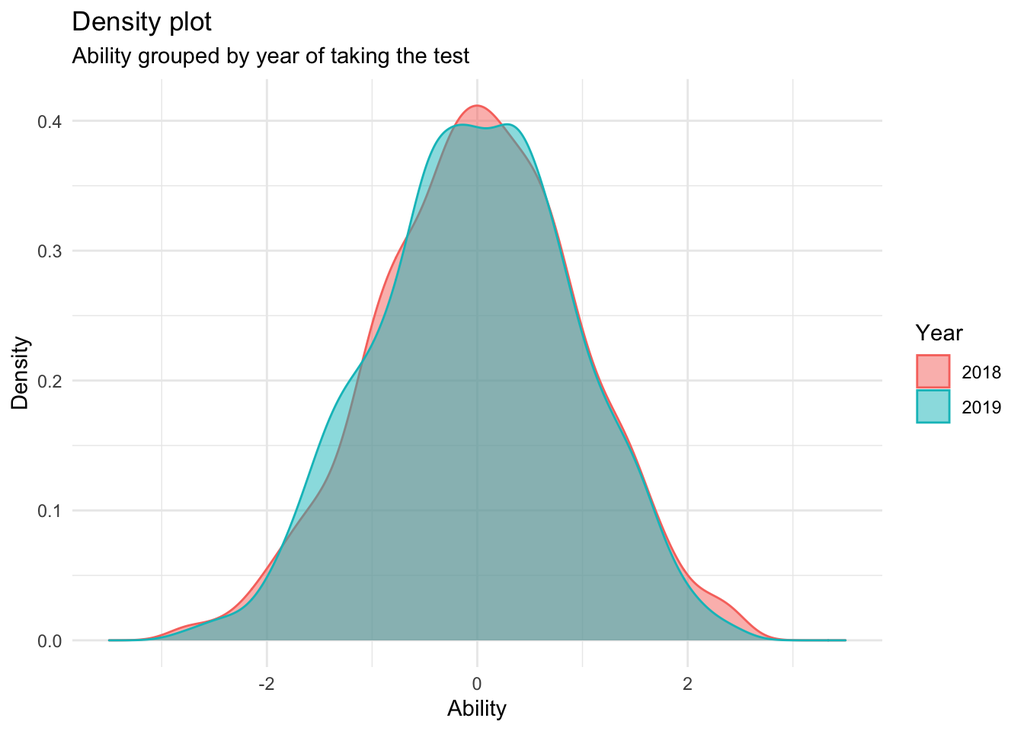

```r
ggplot(eth_entry_test, aes(F1, fill = as.factor(year), colour = as.factor(year))) +
  geom_density(alpha=0.5) +
  scale_x_continuous(limits = c(-3.5,3.5)) +
  labs(title = "Density plot",
       subtitle = "Ability grouped by year of taking the test",
       x = "Ability", y = "Density",
       fill = "Year", colour = "Year") +
  theme_minimal()
```

There does not seem to be a big difference between the two year groups, so we combine them in the following analysis.

#### Differences between classes

Compare the distribution of abilities in the various classes.

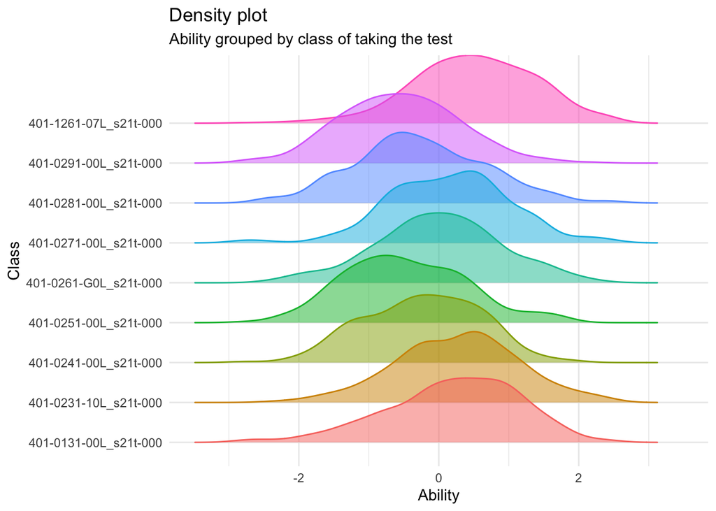

```r
ggplot(eth_entry_test, aes(x = F1, y = class, colour = class, fill = class)) +
  geom_density_ridges(alpha = 0.5) +
  scale_x_continuous(limits = c(-3.5,3.5)) +
  guides(fill = FALSE, colour = FALSE) +
  labs(title = "Density plot",
       subtitle = "Ability grouped by class of taking the test",
       x = "Ability", y = "Class") +
  theme_minimal()
```

```r
knitr::knit_exit()
```